# act_report

## Report: act_report

WeRateDogs is an exciting twitter page that humorously rates dogs of different breeds and stages. A feature unique to these ratings is how dogs are rated above the rate-scale which is 10. These ratings can be as high as 15, even more. This, according to the handler is because they are good dogs.

[figure not shown]

[figure not shown]

An archive of WeRateDogs' tweets which was readily available, a dataset which contains dog_breed prdictions by a neural network of the rated dogs and a last dataset that contains favorite and retweet count queried via Twitter API were wrangled to obtain a single and high-quality dataset which included original ratings only. An exploratory analysis was carried out on the final dataset to get some insights too. This led to asking the following questions;

1. **What year did the handler make the most ratings?**

Year 2016 had the highest number of ratingss of the three years. About 1000 dogs were rated in this year.

1. **What percentage of the dogs had a rating of more than 10?**

57.93% of the dogs rated had a rating of >10.

1. **Which are the top 5 most rated dogs breeds?**

The top 5 most rated breeds of dog are;

1. Golden_Retriever 155
2. Labrador_Retriever 103
3. Pembroke 94
4. Chihuahua 90
5. Pug 62

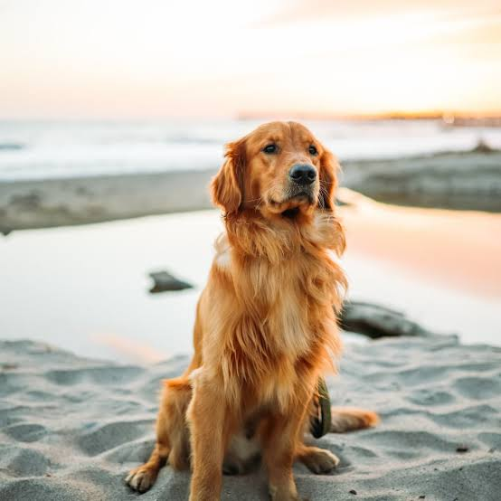

```
                                                    A Golden Retriever
```

1. **Which dog stage was mostly rated?**

   According to the Dogtionary,

   Doggo: an older version of a pupper, a dog that understands tasks.

   Pupper: a younger doggo, inexperienced, unfamiliar or unprepared for responsibilities associated with being a doggo.

   Puppo: a transitional phase between a pupper and a doggo.

   Floofer: a dog that has excess fur.

Most of the dogs rated were in the Pupper dog stage.

[figure not shown]

```
                                                    A Pupper
```